# Classwork 7.2

# Loading Packages

# Classwork 7.2 - Modeling Error

# Classwork 7.2 - The “Complex” Model

```r
library(fivethirtyeight)
drinks$Country <- drinks$country
happydrinks <- left_join(HappyPlanetIndex, drinks, by = "Country")
head(happydrinks)
```

|  | Country | Region | Happiness | LifeExpectancy | Footprint | HLY | HPI | HPIRank | GDPperCapita | HDI | Population | country | beer_servings | spirit_servings | wine_servings | total_litres_of_pure_alcohol |
| --- | --- | --- | --- | --- | --- | --- | --- | --- | --- | --- | --- | --- | --- | --- | --- | --- |
| 1 | Albania | 7 | 5.5 | 76.2 | 2.2 | 41.7 | 47.91 | 54 | 5316 | 0.801 | 3.15 | Albania | 89 | 132 | 54 | 4.9 |
| 2 | Algeria | 3 | 5.6 | 71.7 | 1.7 | 40.1 | 51.23 | 40 | 7062 | 0.733 | 32.85 | Algeria | 25 | 0 | 14 | 0.7 |
| 3 | Angola | 4 | 4.3 | 41.7 | 0.9 | 17.8 | 26.78 | 130 | 2335 | 0.446 | 16.10 | Angola | 217 | 57 | 45 | 5.9 |
| 4 | Argentina | 1 | 7.1 | 74.8 | 2.5 | 53.4 | 58.95 | 15 | 14280 | 0.869 | 38.75 | Argentina | 193 | 25 | 221 | 8.3 |
| 5 | Armenia | 7 | 5.0 | 71.7 | 1.4 | 36.1 | 48.28 | 48 | 4945 | 0.775 | 3.02 | Armenia | 21 | 179 | 11 | 3.8 |
| 6 | Australia | 2 | 7.9 | 80.9 | 7.8 | 63.7 | 36.64 | 102 | 31794 | 0.962 | 20.40 | Australia | 261 | 72 | 212 | 10.4 |

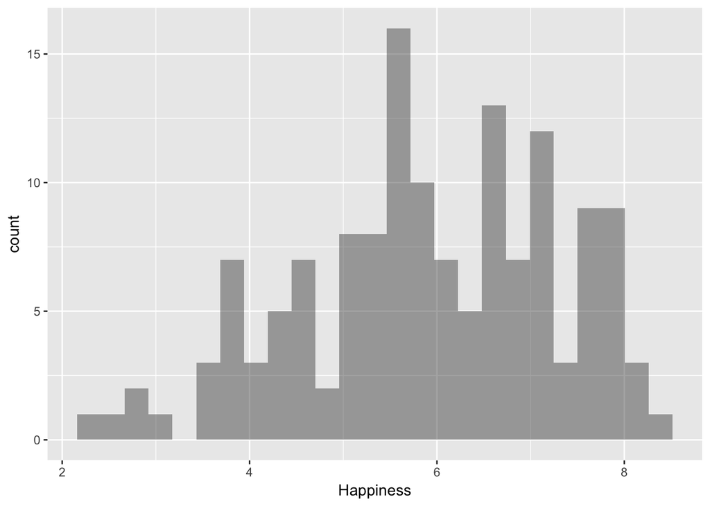

```r
gf_histogram(~ Happiness, data = happydrinks)
```

```r
favstats(~ Happiness, data = happydrinks)
```

|  | min | Q1 | median | Q3 | max | mean | sd | n | missing |
| --- | --- | --- | --- | --- | --- | --- | --- | --- | --- |
|  | 2.4 | 5 | 5.9 | 7 | 8.5 | 5.918881 | 1.373233 | 143 | 0 |

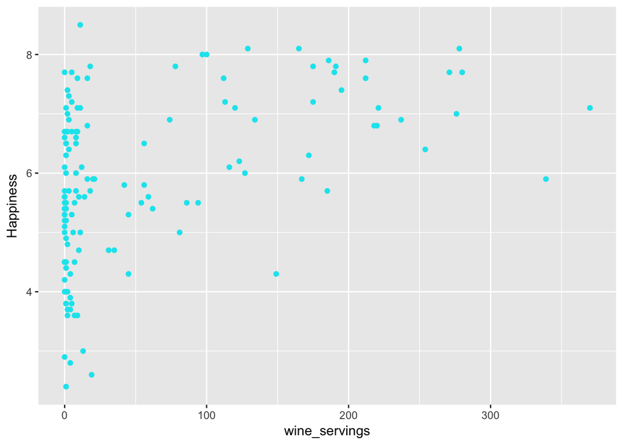

```r
gf_point(Happiness ~ wine_servings, data = happydrinks, color = "turquoise2")
```

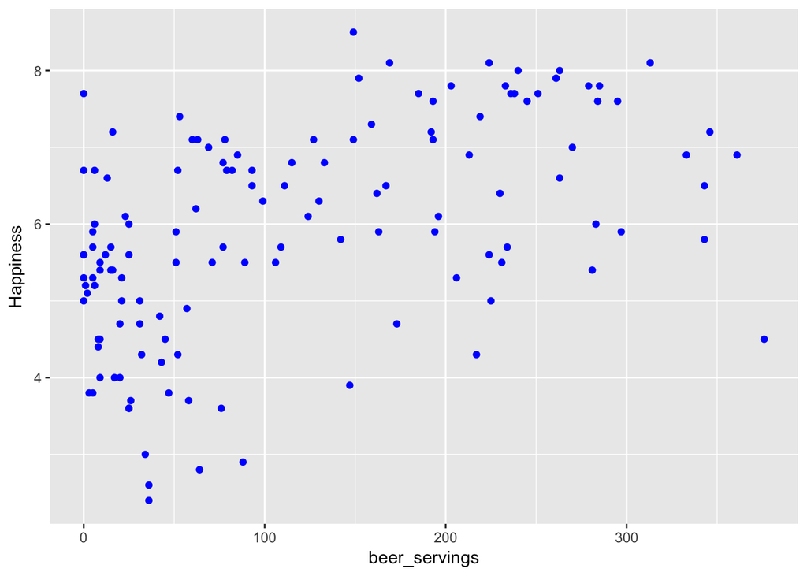

```r
gf_point(Happiness ~ beer_servings, data = happydrinks, color = "blue")
```

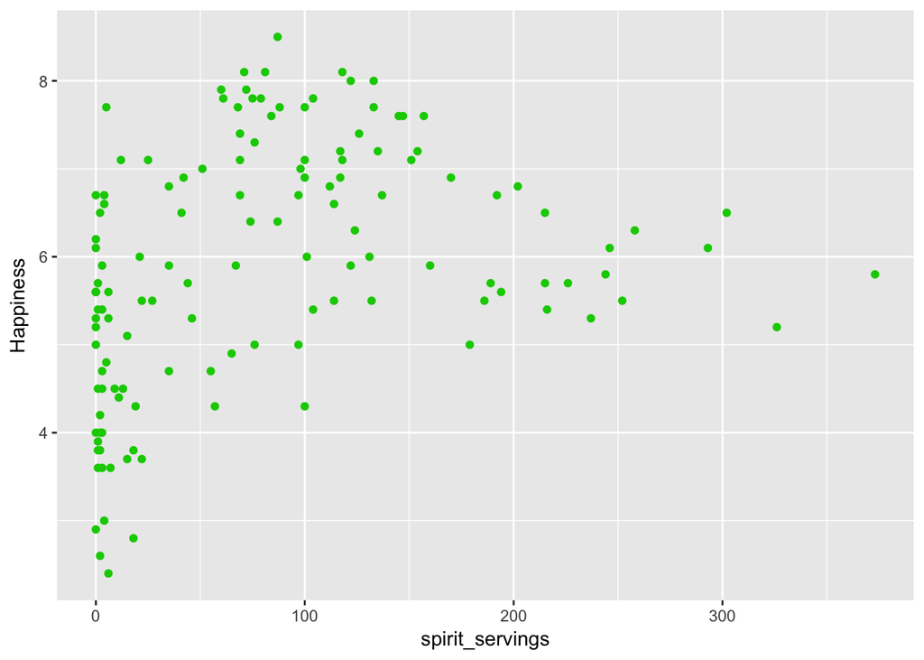

```r
gf_point(Happiness ~ spirit_servings, data = happydrinks, color = "green3")
```

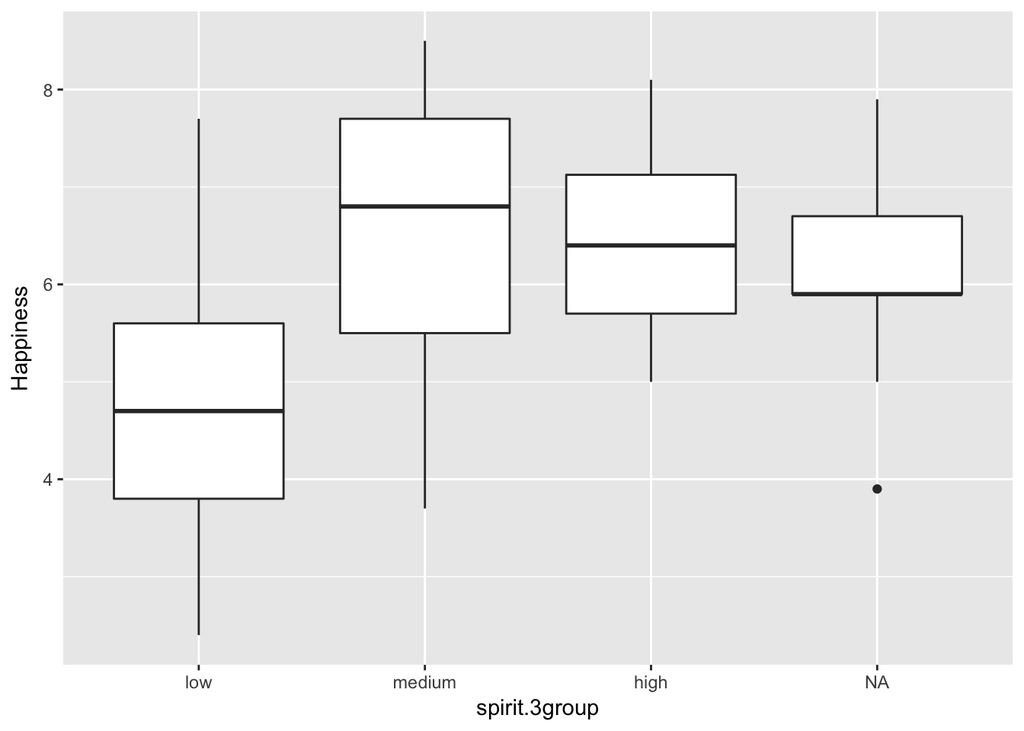

```r
happydrinks$spirit.3group <- ntile(happydrinks$spirit_servings, 3)
happydrinks$spirit.3group <- factor(happydrinks$spirit.3group, levels = c(1,2,3), labels = c("low", "medium", "high"))

gf_boxplot(Happiness ~ spirit.3group, data = happydrinks)
```

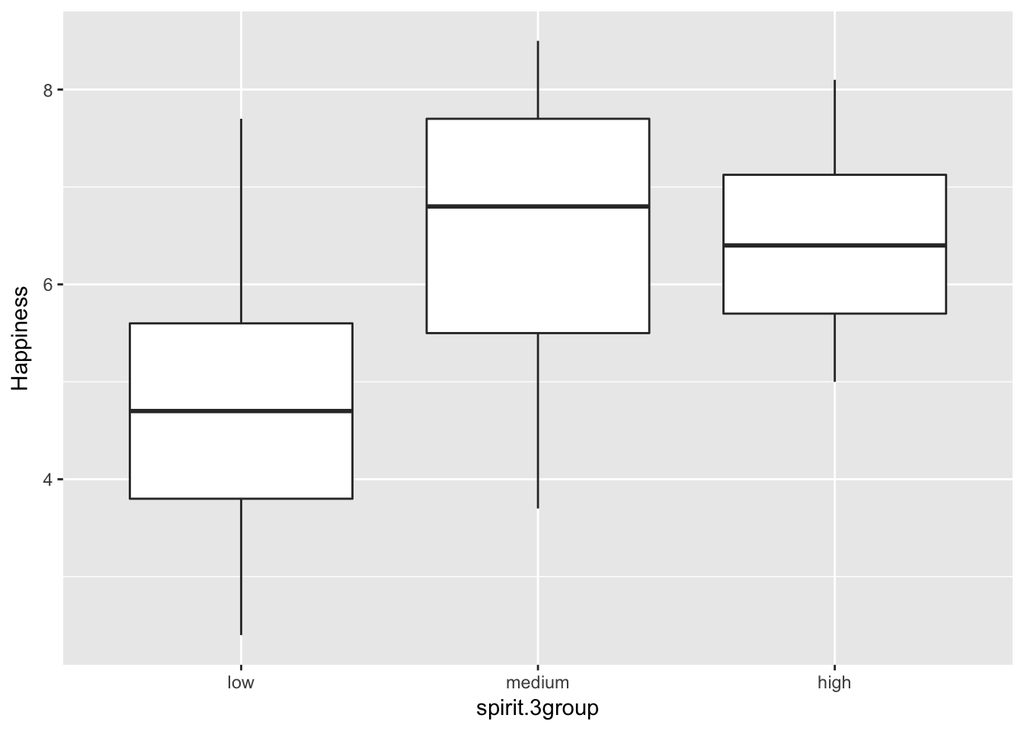

```r
happydrinks <- filter(happydrinks, spirit.3group != "NA")
gf_boxplot(Happiness ~ spirit.3group, data = happydrinks)
```

Just so we remember what we were talking about in Week 6…

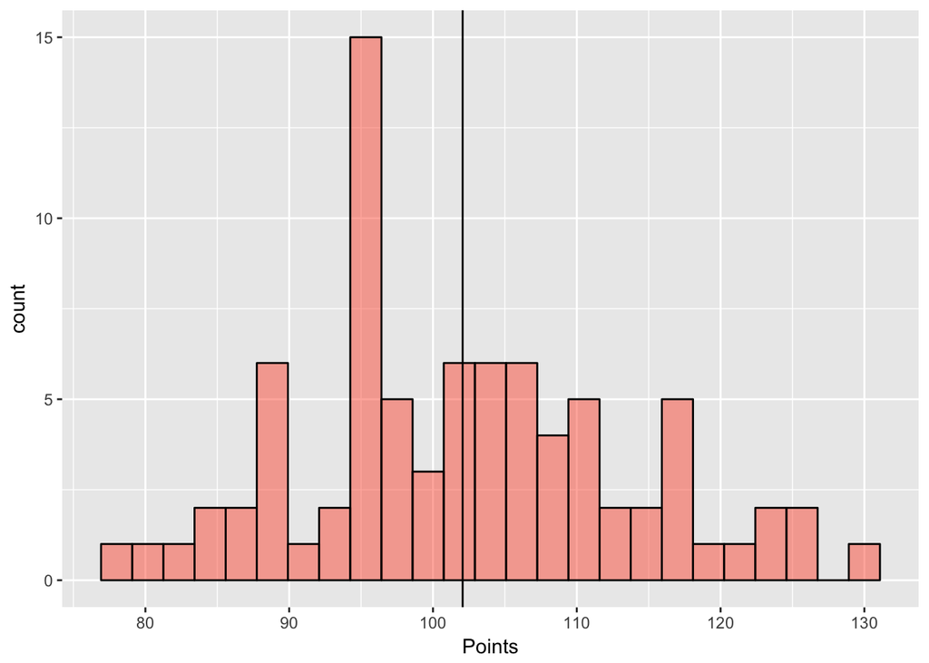

```r
Points.stats <- favstats(~ Points, data = MiamiHeat)

gf_histogram(~ Points, data = MiamiHeat, fill = "tomato", color = "black") %>%
  gf_vline(xintercept = ~mean, data = Points.stats)
```

# Sum of Squares with R

Different ways of calculating sum of squares in R. Here are three ways of finding sum of squares (for Points) in R.

## Using anova()

```r
empty.model <- lm(Points ~ NULL, data = MiamiHeat)
anova(empty.model)
```

|  | Df | Sum Sq | Mean Sq | F value | Pr(>F) |
| --- | --- | --- | --- | --- | --- |
| Residuals | 81 | 10484.7 | 129.4407 | NA | NA |

## Find at least one other way of calculating Sum of Squres

This is the long way where we save every step of the process.

```r
# finding the residuals
MiamiHeat$Residual <- resid(empty.model)
MiamiHeat$SqResidual <- MiamiHeat$Residual^2

head(select(MiamiHeat, Points, Residual, SqResidual))
```

|  | Points | Residual | SqResidual |
| --- | --- | --- | --- |
| 1 | 80 | -22.060976 | 486.686645 |
| 2 | 97 | -5.060976 | 25.613474 |
| 3 | 96 | -6.060976 | 36.735425 |
| 4 | 101 | -1.060976 | 1.125669 |
| 5 | 129 | 26.939024 | 725.711035 |
| 6 | 93 | -9.060976 | 82.101279 |

```r
sum(MiamiHeat$SqResidual)
```

```
## [1] 10484.7
```

You could also just combine all those steps into one line.

```r
# combining all those steps into one line
sum(resid(empty.model)^2)
```

```
## [1] 10484.7
```

# Pros and Cons of SS

### What is good about SS?

- The SS is minimized if the mean is the model.
- Eventually if you square and sum up the residuals, that’s gonna be cool. Other things are going to add up to SS, perfectly, like Pythagorean Theorem.

### What is the problem with SS? (That is, why do we need Variance and Standard Deviation?)

- It gets bigger with more data points.
- Variance fixes SS because it doesn’t get bigger just because you have more data points. Variance is bigger when the distribution is more spread out (aka it has more variation).
- StDeviation also does not get bigger with more data points. StDeviation is bigger when the distribution is more spread out (aka it has more variation)

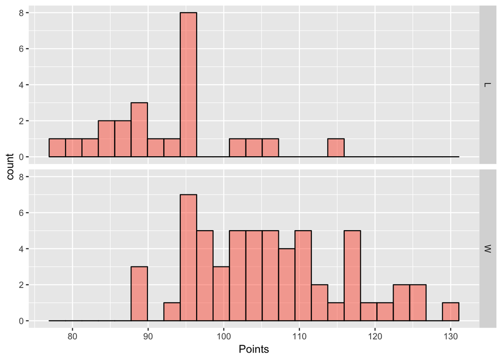

```r
# Make a faceted histogram of Points by Win (winning games vs. losing games)
gf_histogram(~ Points, data = MiamiHeat, fill = "tomato", color = "black") %>%
  gf_facet_grid(Win ~ .)
```

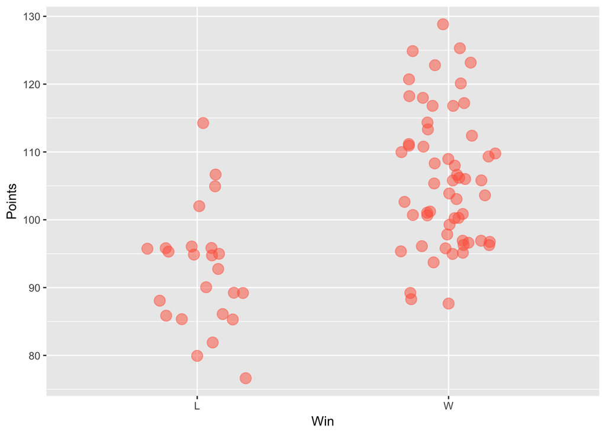

```r
# Bonus: Make a jitter plot of Points by Win
gf_jitter(Points ~ Win, data = MiamiHeat, color = "tomato", size = 4, alpha = .5, width = .2)
```

Wins and Losses are not that different in how variable those games are (maybe Wins are a little more spread out but not by much). But Wins have A WAY BIGGER SS. Why? There are more wins. More data points means more residuals. More residuals means more squared residuals. More squared residuals means a bigger sum of squares.

```r
# Bonus R exercises
# try saving the data from Winning games into a data frame and find the SS for Wins

# try saving the data from Losing games into a data frame and find the SS for Losses
```

# Seeing Standard Deviation

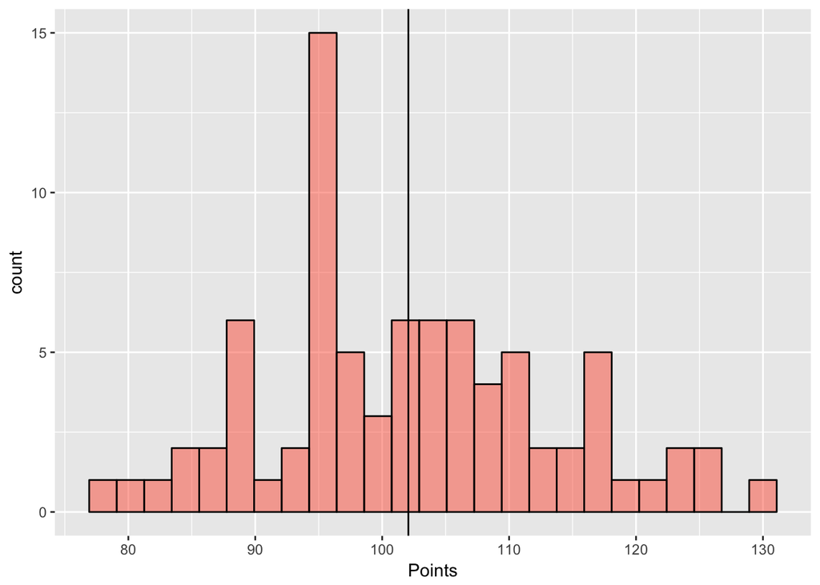

```r
# Make a histogram of Points and put in a line for the mean
gf_histogram(~ Points, data = MiamiHeat, fill = "tomato", color = "black") %>%
  gf_vline(xintercept = ~mean, data = Points.stats)
```

Points: Where is the standard deviation on this histogram? (gesture) If you aren’t sure, ask yourself where are the residuals? SS? Variance? StDev? (gesture)

```r
# Find the standard deviation of Points
favstats(~Points, data = MiamiHeat)
```

|  | min | Q1 | median | Q3 | max | mean | sd | n | missing |
| --- | --- | --- | --- | --- | --- | --- | --- | --- | --- |
|  | 77 | 95 | 101 | 109.75 | 129 | 102.061 | 11.3772 | 82 | 0 |

Come up with a strategy to try to “see” the standard deviation in the histogram of Points.

Test your strategy: Estimate the Standard Deviation of Assists

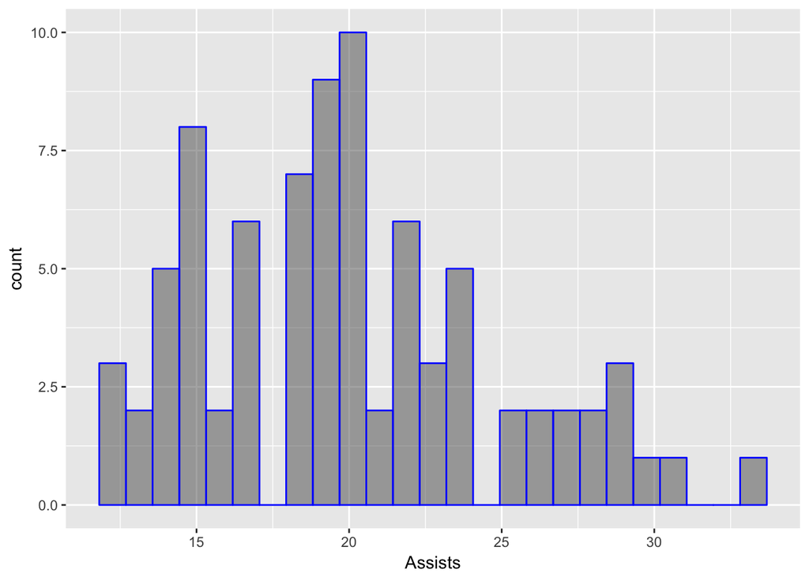

```r
# Make a histogram of Assists and estimate the standard deviation
gf_histogram(~ Assists, data = MiamiHeat, color = "blue")
```

Your estimate: around 5

```r
# Calculate the standard deviation of Assists
favstats(~ Assists, data = MiamiHeat)
```

|  | min | Q1 | median | Q3 | max | mean | sd | n | missing |
| --- | --- | --- | --- | --- | --- | --- | --- | --- | --- |
|  | 12 | 17 | 19 | 23 | 33 | 19.9878 | 4.852119 | 82 | 0 |

Test your strategy: Estimate the Standard Deviation of FG3

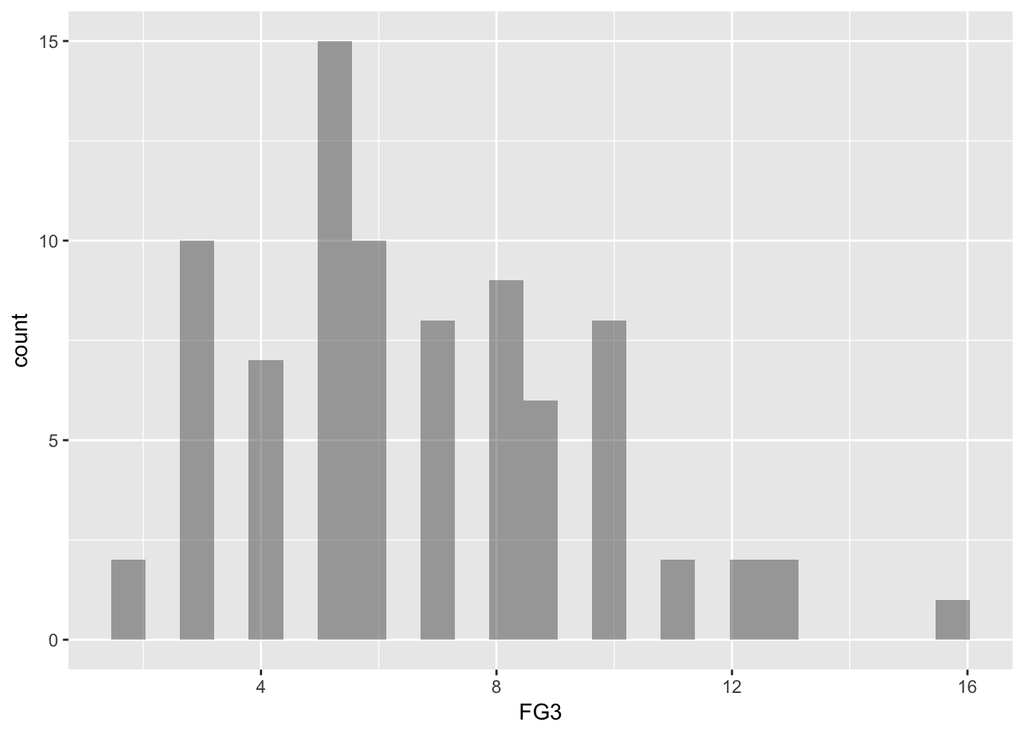

```r
# Make a histogram of FG3 and estimate the standard deviation
gf_histogram(~ FG3, data = MiamiHeat)
```

Your estimate: around 3

```r
# Calculate the standard deviation of FG3
favstats(~ FG3, data = MiamiHeat)
```

|  | min | Q1 | median | Q3 | max | mean | sd | n | missing |
| --- | --- | --- | --- | --- | --- | --- | --- | --- | --- |
|  | 2 | 5 | 6 | 8.75 | 16 | 6.670732 | 2.884847 | 82 | 0 |